# IBM Attrition Dataset Analysis

Tony Kwang Hyun Kim

12/7/2020

## Thoughts on the Dataset & Project

The IBM HR Analytics Employee Attrition & Performance dataset has become one of the most well recognized datasets for those interested in people analytics. Although the dataset is a fictional, it includes various HR metrics commonly collected in various organizations today.

The data is perfect for those interested in practicing data analytics skills; however, it should not be used as a template in organizational settings. My reasons are as follows:

First, it is important to note that the dataset simplifies few metrics and does not provide additional information on how each construct was measured or what each construct means. For example, let’s take **job satisfaction** which was measured on a scale of 1 to 4 (1 = low, 2 = medium, 3= high 4 = very high). In the organizational psychology literature, there various scales which measures and defines job satisfaction differently. Without knowing how an organization measures or defines these constructs, it may be difficult to understand why an effect is taking place.

Second, I would like to note how dangerous it can be to utilize some of the metrics included in the dataset for business decisions. Based on your region’s labor regulations, you may be exposing you and your organization to potential discrimination charges. I advise you to consult with your legal team before making any decisions.

Overall, I loved playing with the dataset. I think it provides a glimpse of what people analytics can be like. Let me show you how I would’ve approached the dataset if I was in a real organizational setting.

## Introduction

For organizations, turnover is often extremely costly. Resources must be allocated to finding a suitable replacement, and even after finding someone, the organization must invest in the replacement’s learning and development. Because turnover comes at a premium, organizational psychologists often use turnover as a way to persuade company leaders to better care for their employees. This is one reason why I believe company culture, engagement, and well-being have recently become such hot topics.

Therefore with this dataset, I will strive to identify the reasons why individuals may be leaving the organizations. Therefore I will attempt the following:

1. **Data Wrangling**
2. **Exploratory Data Analysis**
3. **Inferential Analysis**
4. **Provide Recommendations based on Organizational Psychology Literature**

Note that I will not be creating a prediction model. Rather than trying to predict, the goal is to analyze why employees have left.

*Side Note* Although the data is fictional, I have attempted to treat the data as a real-world dataset.

### Loading Libraries & Dataset

**Loading Libraries**

```r
library(readr)
library(ggplot2)
library(ggcorrplot)
library(dplyr)
library(ggthemes)
library(scales)
library(ggthemr)
library(fabricatr)
library(Hmisc)
library(forcats)
install.packages("ggthemr")
knitr::opts_chunk$set(message = FALSE, warning = FALSE, fig.width=8, fig.height =6)
```

**Loading Data**

```r
ibm_data <- read_csv("data/ibm_dataset/WA_Fn-UseC_-HR-Employee-Attrition.csv")
names(ibm_data)
```

```
##  [1] "Age"                      "Attrition"
##  [3] "BusinessTravel"           "DailyRate"
##  [5] "Department"               "DistanceFromHome"
##  [7] "Education"                "EducationField"
##  [9] "EmployeeCount"            "EmployeeNumber"
## [11] "EnvironmentSatisfaction"  "Gender"
## [13] "HourlyRate"               "JobInvolvement"
## [15] "JobLevel"                 "JobRole"
## [17] "JobSatisfaction"          "MaritalStatus"
## [19] "MonthlyIncome"            "MonthlyRate"
## [21] "NumCompaniesWorked"       "Over18"
## [23] "OverTime"                 "PercentSalaryHike"
## [25] "PerformanceRating"        "RelationshipSatisfaction"
## [27] "StandardHours"            "StockOptionLevel"
## [29] "TotalWorkingYears"        "TrainingTimesLastYear"
## [31] "WorkLifeBalance"          "YearsAtCompany"
## [33] "YearsInCurrentRole"       "YearsSinceLastPromotion"
## [35] "YearsWithCurrManager"
```

```r
class(ibm_data)
```

```
## [1] "spec_tbl_df" "tbl_df"      "tbl"         "data.frame"
```

```r
# setting up second dataset for wrangling and analysis
data1 <- ibm_data
```

### Wrangling Data

Before any analysis, it is critical for the data to be cleaned. For anyone interested in what a clean data looks like, I highly recommend reading Hadley Wickham’s paper on “Tidy Data” [Link](https://vita.had.co.nz/papers/tidy-data.pdf).

Overall, the data is relatively clean and follows the principle of “Tidy Data”. However, there are additional checks

Key Questions:

1. **Missing Data:** are there missing data that we need to account for?
2. **Column Classes:** are all the column classes set to the appropriate class?
3. **Irrelevant Data:** are there any data that we don’t need for the analysis?
4. **Data Error Checks:** are there any data errors (e.g. collection, recording, or entry errors) that should be accounted for?

#### Checking for Missing Data

**Counting all NA values within each column.**

```r
colSums(is.na(data1))
```

```
##                      Age                Attrition           BusinessTravel
##                        0                        0                        0
##                DailyRate               Department         DistanceFromHome
##                        0                        0                        0
##                Education           EducationField            EmployeeCount
##                        0                        0                        0
##           EmployeeNumber  EnvironmentSatisfaction                   Gender
##                        0                        0                        0
##               HourlyRate           JobInvolvement                 JobLevel
##                        0                        0                        0
##                  JobRole          JobSatisfaction            MaritalStatus
##                        0                        0                        0
##            MonthlyIncome              MonthlyRate       NumCompaniesWorked
##                        0                        0                        0
##                   Over18                 OverTime        PercentSalaryHike
##                        0                        0                        0
##        PerformanceRating RelationshipSatisfaction            StandardHours
##                        0                        0                        0
##         StockOptionLevel        TotalWorkingYears    TrainingTimesLastYear
##                        0                        0                        0
##          WorkLifeBalance           YearsAtCompany       YearsInCurrentRole
##                        0                        0                        0
##  YearsSinceLastPromotion     YearsWithCurrManager
##                        0                        0
```

Results: No missing data.

#### Checking and Changing Column Classes

Checking the classes of all the columns.

```r
str(data1)
```

Checking if all of the character columns are appropriate factor variables.

```r
table(data1$Attrition)
table(data1$BusinessTravel)
table(data1$Department)
table(data1$EducationField)
table(data1$Gender)
table(data1$JobRole)
table(data1$MaritalStatus)
table(data1$Over18)
table(data1$OverTime)
```

[output not shown]

I check for the table for all of the character class columns because my hunch is that they are all factor (categorial) variables. Checking the table for the columns allows me to evaluate if they are indeed categorical variables. And it allows me to get a better idea of the people of the organization.

Based on the table information of each of the character columns(), the character class columns are all factor variables and should be converted to such.

Changing character class columns into factor class.

```r
for(i in 1:dim(data1)[2]){
    if(class(data1[[i]]) == "character"){
        data1[[i]] <- as.factor(data1[[i]])
    }
}
```

#### Checking for Irrelevant Data.

Often times, irrelevant data are peppered into the dataset. I like to remove irrelevant variables to keep my dataset neat and slim as much as possible (stylistic preference). However, if you or the organization are planning to add on to the dataset or foresee this being a long term project, I would recommend not taking any variables out. However, since this is a completed dataset with no plans to add more participants, I will be removing irrelevant variables Additionally, datasets often includes participant identity variables such as names, computer id, etc.; all of which should be removed to insure participant anonymity.

*Irrelevancy should be determined with careful consideration and should be discussed with relevant stakeholders*

Considering Irrelevancy

```r
summary(data1)
```

[output not shown]

Take Out: EmployeeCount: all partipants are labeled as 1 StandardHours: all partipants have 80 Over 18: all participant are over 18

Taking out Irrelevant Data

```r
data2 <- subset(data1, select = -c(EmployeeCount, StandardHours, Over18))
```

#### Data Error Check:

When dealing with people metrics some causes of errors are as follows:

1. **Data Collection, Entry, & Recording Errors:** When not using an online survey tool such as Qualtrics, SurveyMonkey, etc., an individual will need to collect, enter, and record the data. Errors can occur in any of the three steps. Although the best way to inhibit error is to have a checking system before it reaches the data analyst, I can do the following to check:
   - Check for extreme outliers. This will check if someone accidentally added or subtracted a number (e.g. putting 100 instead of 10)
   - Check for numbers outside the expected range. (e.g. if a survey scale is from 1:4, checking if there are any numbers outside that range.)
2. **Laziness:** When dealing with survey data, it is critical to have a system in place to check for human laziness. For one, participants may “straightline” which is when participants select the same answer for every question. In addition, participants may hastily speed through the survey, providing inaccurate responses. I can do the following to check:
   - If using surveys, add multiple questions to check for attentiveness (e.g. have a question on the survey request the participant select choice #4)
   - Look at the average time it took for people to answer the survey. Remove participants who have finished at an “unreasonable” time span.
   - Check if people chose the same answer for each survey question. I will show a function below.

Preliminary Check for Data Errors

I use the summary function to see if the min and max values of each variable seem to make sense. Here I am checking for any unreasonable min and max values (extreme outliers + numbers outside exxpected range).

```r
summary(data2)
```

[output not shown]

Found all of the min and max values of factor variables and survey questions to be within their appropriate range. **However, without knowledge of the company, I could not properly evaluate the other variables.**

Checking if all survey questions were answered the same. (Checking for straightlining)

```r
survey_cols <- c(10, 13, 16, 24, 28)
survey_variables <- data2[,survey_cols]

which(apply(survey_variables, 1, function(x) length(unique(x))==1))
```

```
##  [1]  134  158  194  241  297  351  432  472  497  502  507  547  688  729  858
## [16]  932 1104 1108 1127 1142 1285
```

```r
sum(apply(survey_variables, 1, function(x) length(unique(x))==1))
```

```
## [1] 21
```

Overall, I found 21 participants to have circled the same response for each. However, I will not remove these participants for the following reasons: - All of the survey questions should theoretically be highly correlated with each other, meaning it is not unreasonable to see similar answers. - I do not know the composition of the survey, meaning I do not know if all these questions were next to each other, making it difficult to identify “straightlining.” - There are too few questions for me to comfortably declare straightlining.

Setting up data to use for EDA

```r
f_data <- data2
```

**Therefore, I will be using f_data (final data) as my data set for EDA & inferential analysis**

## Exploratory Data Analysis

The purpose of the EDA is to help me understand the data and help me form my hypotheses. At an initial glance of the variables, employees are divided structurally by the following:

- Job Role
- Department
- Job Level.

I will initially take a look at the attrition distribution of those three divisions. Then I will investigate if attrition rate differs for varying groups within these divisions. These are:

- Demographic Variables
- Income Variables
- Satisfaction Variables
- Performance Variables

### Overall Attrition Distribution

**Summary:** After looking at the attrition distribution as a whole and then by job role, department, and job level here are my following insights:

1. Overall, **16% of the company is leaving**. Having comparative metrics such as competitor’s attrition rates would help understand the value of this 16%.
2. **Sales Reps had the highest within job role attrition rate at 40%.** Meaning that 40% of sales rep employees left. Laboratory technicians and human resources had the next highest with 24% and 23%.
3. In terms of departments, the attrition rate within departments did not vary as much seeing how the sales, hr, and r&d had an attrition rate of 21%, 19%, and 14% respectively.
4. As expected, **those in level 1 had the highest within attrition rate at 26%.** However, there was a slight increase in attrition rate from level 2 to level 3 with level 2 having a within attrition rate of 10% with level 3 at 15%.

**Final thoughts:** The most concerning irregularities comes when looking at individuals from different job roles. Sales reps at 40% attrition is an alarming number. Although less shocking, individuals from level 1 are also leaving at a higher rate of 26%. Identifying the key drivers of attrition especially at the noted job role and levels will be critical. Therefore, once looking at the data, I decided to focus my analysis on job role and level. Departmental analysis will be done for another time.

#### Supporting Analysis

**Overall Attrition Distribution**

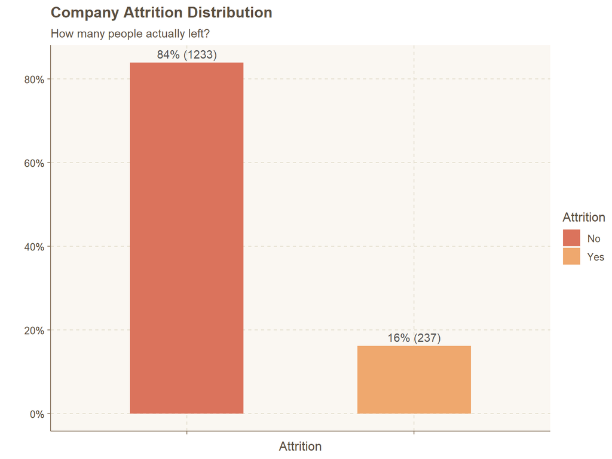

```r
ggthemr('dust')
f_data %>%
  count(Attrition) %>%
  mutate(pct = prop.table(n)) %>%
  mutate(name = paste(round(pct,2)*100,"%", " (", n, ")", sep = "")) %>%
  ggplot(aes(x = Attrition, y = pct, fill = Attrition)) +
    geom_col(position = 'dodge', width = .5) +
    geom_text(aes(label = name), vjust = -.5) +
    scale_y_continuous(labels = scales::percent) +
    labs(x = "Attrition", y = "", title = "Company Attrition Distribution", subtitle = "How many people actually left?") +
    theme(axis.text.x = element_blank())
```

**Quick Takeaways:**

- Organization had a 16% attrition rate with 237 people having left.
- Imbalance between those who left and those who didn’t.

**Attrition Within Job Role**

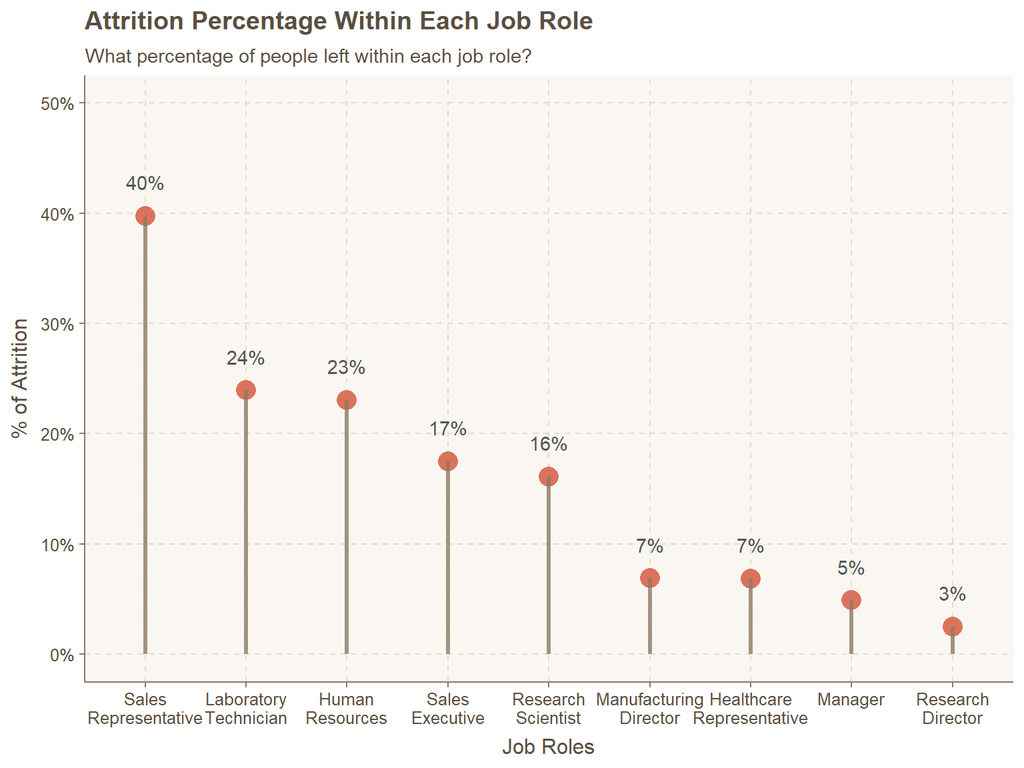

```r
f_data %>%
  group_by(JobRole) %>%
  count(Attrition) %>%
  mutate(pct = prop.table(n)) %>%
  mutate(name = paste(round(pct,2)*100,"%", sep = "")) %>%
  mutate(JobRole = gsub(" ", "\n", JobRole)) %>%
  subset(Attrition == "Yes") %>%
  ggplot(aes(x = reorder(JobRole, -pct), y = pct)) +
  geom_point(size = 5, aes(y = pct)) +
  geom_segment(aes(x = JobRole, xend= JobRole, y = 0, yend = pct),
    size = 1.2, linetype = 1, alpha = .8, color = "#8d7a64") +
  labs(title = "Attrition Percentage Within Each Job Role",
    subtitle = "What percentage of people left within each job role?",
    x = "Job Roles",
    y = "% of Attrition") +
  geom_text(aes(label = name, x = JobRole, y= pct), vjust = -1.8) +
  scale_y_continuous(labels = scales::percent_format(accuracy = 1), limits = c(0, .5))
```

**Quick Takeaways:**

- Sales representatives had the highest percentage of people leaving while research director and managers had the lowest percentage.

**Attrition Within Each Department**

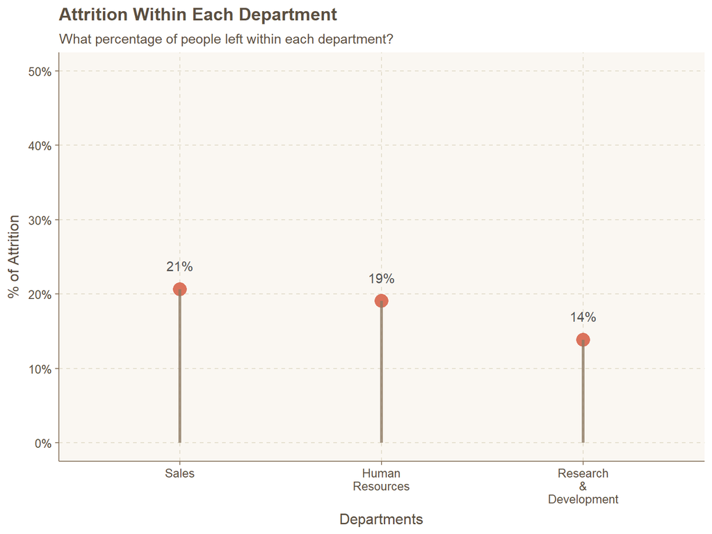

```r
f_data %>%
  group_by(Department) %>%
  count(Attrition) %>%
  mutate(pct = prop.table(n)) %>%
  mutate(name = paste(round(pct,2)*100,"%", sep = "")) %>%
  mutate(Department = gsub(" ", "\n", Department)) %>%
  subset(Attrition == "Yes") %>%
  ggplot(aes(x = reorder(Department, -pct), y = pct)) +
  geom_point(size = 5, aes(y = pct)) +
  geom_segment(aes(x = Department, xend= Department, y = 0, yend = pct),
    size = 1.2, linetype = 1, alpha = .8, color = "#8d7a64") +
  labs(title = "Attrition Within Each Department",
    subtitle = "What percentage of people left within each department?",
    x = "Departments",
    y = "% of Attrition") +
  geom_text(aes(label = name, x = Department, y= pct), vjust = -1.8) +
  scale_y_continuous(labels = scales::percent_format(accuracy = 1), limits = c(0, .5))
```

**Quick Takeaways:**

- Unlike job roles, each department didn’t differ as much in terms of the percentage of people leaving. This leads me to think that other factors rather than departmental issues are more likely to affect attrition

**Attrition Within Job Level**

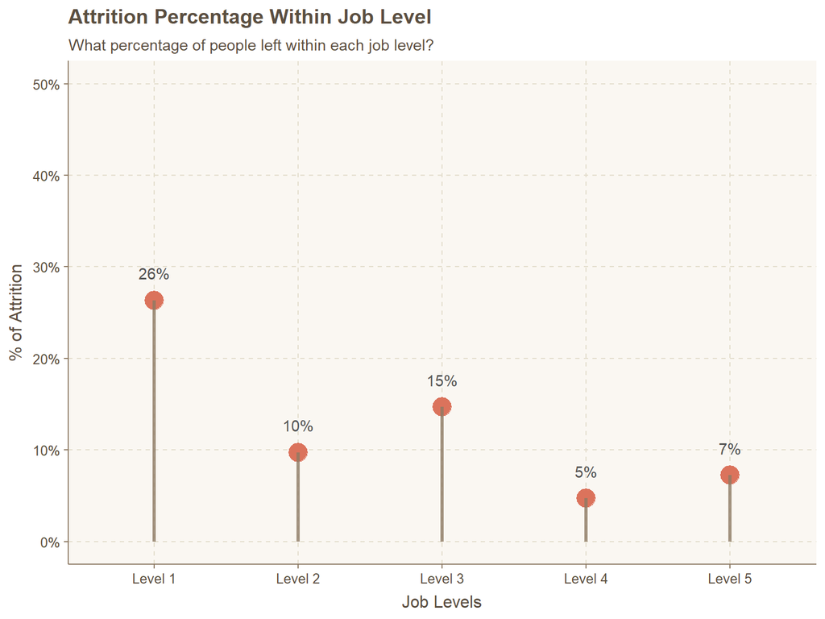

```r
f_data %>%
  group_by(JobLevel) %>%
  count(Attrition) %>%
  mutate(pct = prop.table(n)) %>%
  mutate(name = paste(round(pct,2)*100,"%", sep = "")) %>%
  mutate(JobLevel = paste("Level", JobLevel)) %>%
  subset(Attrition == "Yes") %>%
  ggplot(aes(x = JobLevel, y = pct)) +
  geom_point(size = 6, aes(y = pct)) +
  geom_segment(aes(x = JobLevel, xend= JobLevel, y = 0, yend = pct),
    size = 1.2, linetype = 1, alpha = .8, color = "#8d7a64") +
  labs(title = "Attrition Percentage Within Job Level",
    subtitle = "What percentage of people left within each job level?",
    x = "Job Levels",
    y = "% of Attrition") +
  geom_text(aes(label = name, x = JobLevel, y= pct), vjust = -1.8) +
  scale_y_continuous(labels = scales::percent_format(accuracy = 1), limits = c(0, .5))
```

**Quick Takeaways:**

- As expected people from the lowest level are leaving than those in higher levels. However, it may be worth while to investigate why there was a slight jump in attrition from level 2 to level 3.

### Demographics Analysis

Therefore, I will evaluate if people in different **age** and **gender** are leaving at different rates. I will ask the following:

- Are people in certain gender or age groups leaving at higher rates?
- Are people in certain gender or age groups in a particular job role or job level leaving at higher rates?

### Demographics Analysis #1: Age

**Final thoughts:** The most concerning irregularities comes when looking at the loss of young talent. It may be possible that there is a culture or policy unfavorable to younger individuals. Further analysis on why younger talents are leaving will be evaluated when looking at income and satisfaction ratings. This high attrition rate may be fine if those who are leaving are lower performers. However, it is a serious issue if high performers are leaving as well.

#### Supporting Analysis

**Age Distribution**

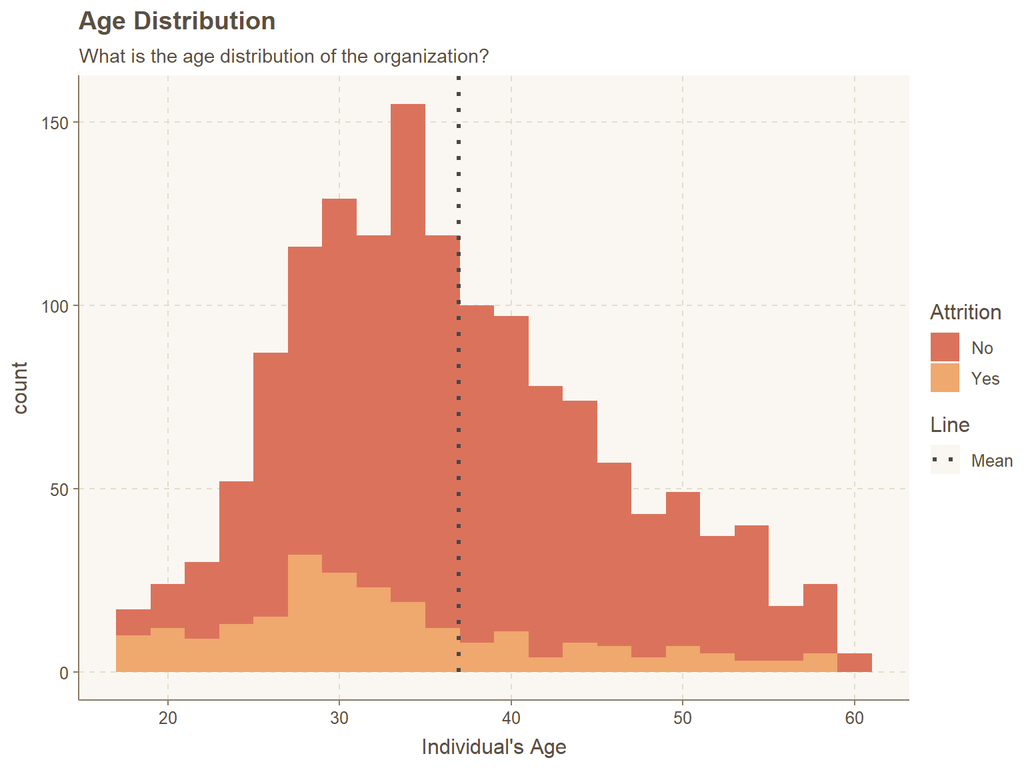

```r
ggthemr("dust")
f_data %>%
  ggplot(aes(x = Age, fill = Attrition)) +
  geom_histogram(binwidth = 2) +
  geom_segment(aes(x = mean(Age), y = 0, xend = mean(Age), yend = Inf, linetype = "Mean"), col = "#484848", lwd = 1.2) +
  labs(x = "Individual's Age", y = "count", title = "Age Distribution", subtitle = "What is the age distribution of the organization?") +
  scale_linetype_manual(name = "Line", values = c("Mean" = 3)) +
  guides(fill = guide_legend(order = 1), linetype = guide_legend(order = 2))
```

**Creating Age Brackets**

```r
AgeQ <- split_quantile(f_data$Age, type = 4)
AgeQ <- as.factor(cut(f_data$Age, breaks = 6,
  labels = c("18-25", "26-32", "33-39", "40-46", "47-53", "54-60")))
table(AgeQ)
```

```
## AgeQ
## 18-25 26-32 33-39 40-46 47-53 54-60
##   123   393   432   282   153    87
```

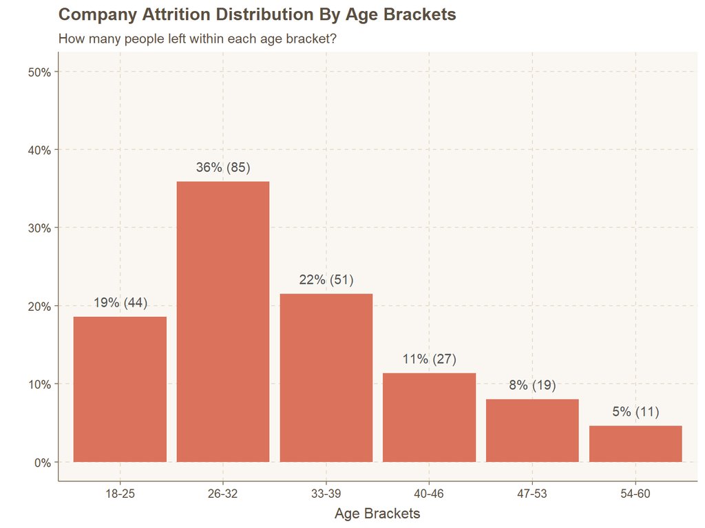

```r
f_data %>%
  select(Age, Attrition) %>%
  mutate(AgeQ = AgeQ) %>%
  filter(Attrition == "Yes") %>%
  group_by(AgeQ) %>%
  summarise(count = n()) %>%
  mutate(pct = prop.table(count),
    label= paste0(round(pct*100,0), "%"," (", count, ")", sep = "")) %>%
  ggplot(aes(x = AgeQ, y = pct)) +
  geom_bar(stat = "identity") +
  geom_text(aes(x = AgeQ, y = pct, label = label),
    vjust = -1) +
  scale_y_continuous(labels = scales::percent_format(accuracy = 1), limits = c(0,.5)) +
  labs(title = "Company Attrition Distribution By Age Brackets",
    subtitle = "How many people left within each age bracket?",
    x = "Age Brackets",
    y = "")
```

**Quick Takeaways:**

- Approximate 55% of all attrition comes from younger employees between 18-32. Overall, it seems as though the company is struggling to maintain younger talent verses older talent.
- The organization seems to be doing well in keeping employees between the age 33-39 considering only a 22% of attrition for the organization’s largest group. The 33-39 age bracket contains their largest number of employees with 432 employees approximately 29.4% of the entire workforce.

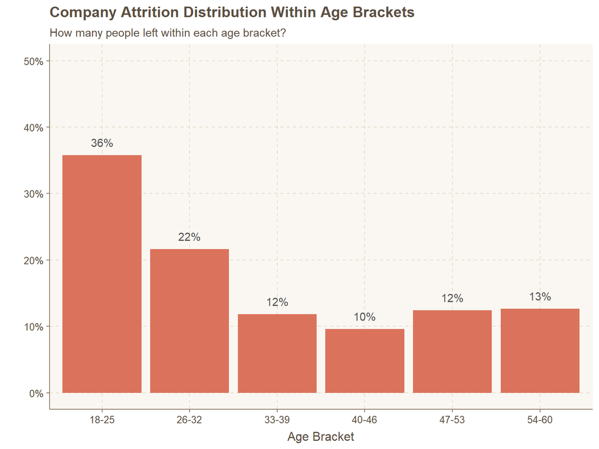

```r
f_data %>%
  select(Age, Attrition) %>%
  mutate(AgeQ = AgeQ) %>%
  group_by(AgeQ, Attrition) %>%
  summarise(count = n()) %>%
  group_by(AgeQ) %>%
  mutate(pct = prop.table(count),
    label= paste0(round(pct*100,0), "%", sep = "")) %>%
  filter(Attrition == "Yes") %>%
  ggplot(aes(x = AgeQ, y = pct)) +
  geom_bar(stat = "identity") +
  geom_text(aes(x = AgeQ, y = pct, label = label),
    vjust = -1) +
  scale_y_continuous(labels = scales::percent_format(accuracy = 1), limits = c(0,.5)) +
  labs(title = "Company Attrition Distribution Within Age Brackets",
    subtitle = "How many people left within each age bracket?",
    x = "Age Bracket",
    y = "")
```

**Quick Takeaways:**

- Overall, 36% of all employees in the 18-25 age bracket left in the given year. That percentage drops to 22% when we go down to the next age bracket.
- Looking at the attrition rates by age bracket and within age bracket, the story continues to indicate that younger people are leaving at a higher rate.

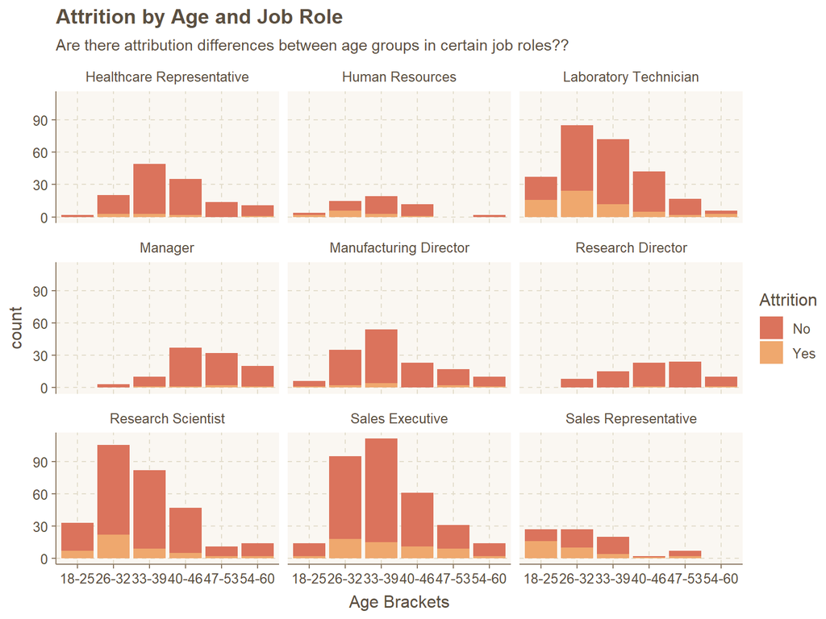

```r
f_data %>%
  select(Age, JobRole, Department, JobLevel, Attrition) %>%
  mutate(AgeQ = AgeQ) %>%
  ggplot(aes(x = AgeQ, fill = Attrition)) +
  geom_bar() +
  facet_wrap(vars(JobRole)) +
  labs(title = "Attrition by Age and Job Role", subtitle = "Are there attribution differences between age groups in certain job roles??",
    x = "Age Brackets")
```

**Quick Takeaways:**

- When we look at attrition by age and job role, things seem relatively normal. People are leaving proportionally to the number of people within the age bracket and job role.
- More than 50% of sales rep between the ages of 18-25 are leaving.

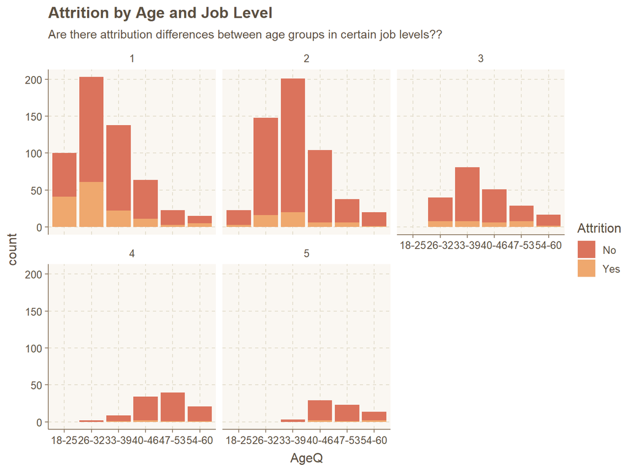

```r
f_data %>%
  select(Age, JobLevel, Attrition) %>%
  mutate(AgeQ = AgeQ) %>%
  ggplot(aes(x = AgeQ, fill = Attrition)) +
  geom_bar() +
  facet_wrap(vars(JobLevel)) +
  labs(title = "Attrition by Age and Job Level", subtitle = "Are there attribution differences between age groups in certain job levels??")
```

**Quick Takeaways:**

- Individuals in the 18-25 age bracket + level 1 are leaving at a higher rate than those in the 26-32 age bracket + level 1.

#### Demographics Analysis #2: Gender

**Summary:** After looking at the attrition distribution separated by **gender** and then gender within job roles and job levels here are my following insights:

1. Males within the organization seems to be leaving at a higher rate than female (14.8% to 17%)
2. Overall, attrition rates between the two gender seem to be proportional within each job role and level

**Final thoughts:** Although not conclusive, the exploratory analysis does not seem to suggest that there were any gender differences in terms of attrition. However, further analysis may be required to ascertain the claim.

#### Supporting Analysis

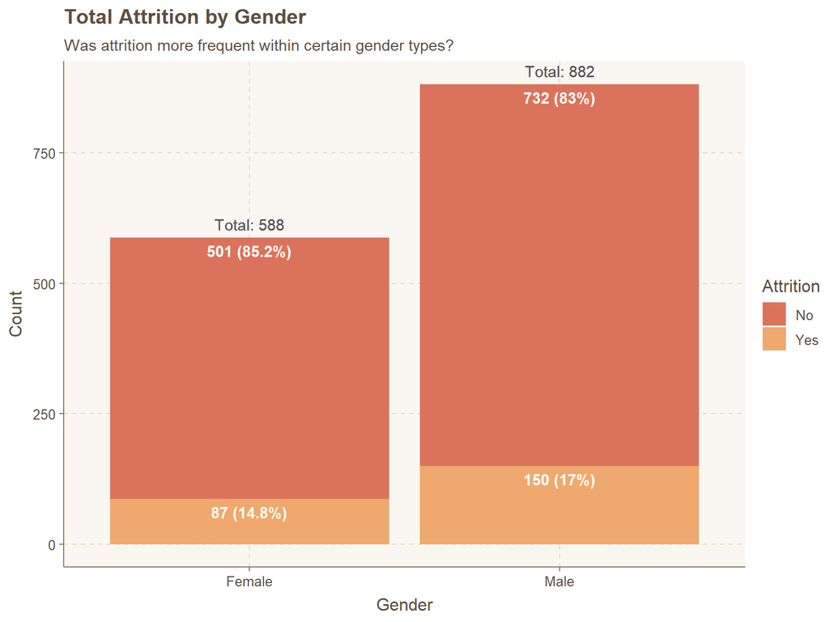

```r
f_data %>%
  select(Attrition, Gender) %>%
  group_by(Attrition, Gender) %>%
  summarise(Count = n()) %>%
  group_by(Gender) %>%
  arrange(Count) %>%
  mutate(Count_total = cumsum(Count),
    CountPer = prop.table(Count),
    final = paste(Count, " (", round(CountPer*100,1), "%)", sep = ""),
    Totals = paste("Total:", sum(Count)),
    Top = sum(Count)) %>%
  ggplot(aes(x = Gender, y = Count, fill = Attrition)) +
  geom_bar(stat = "identity") +
  geom_text(aes(label = final, x = Gender, y = Count_total), vjust = 1.6, color = "white",
    fontface = "bold") +
  geom_text(aes(label = Totals, x = Gender, y = Top), vjust = -.6) +
  labs(title = "Total Attrition by Gender", subtitle = "Was attrition more frequent within certain gender types?")
```

**Quick Takeaways:**

- There are 882 male employees to 588 female employees
- There was a lower percentage of females leaving the organization than males.

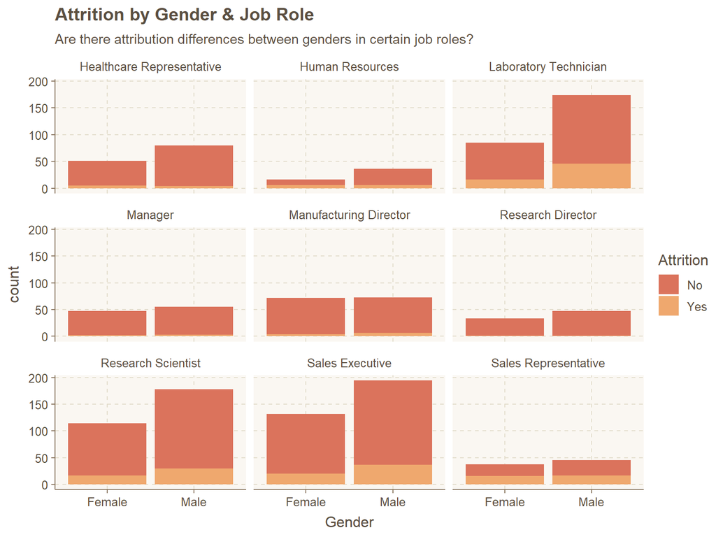

```r
f_data %>%
  ggplot(aes(x = Gender,  fill = Attrition)) +
  geom_bar()  +
  facet_wrap(vars(JobRole)) +
  labs(title = "Attrition by Gender & Job Role",  subtitle = "Are there attribution differences between genders in certain job roles?")
```

**Quick Takeaways:**

- Overall, relatively proportional attrition between genders with all the job role.

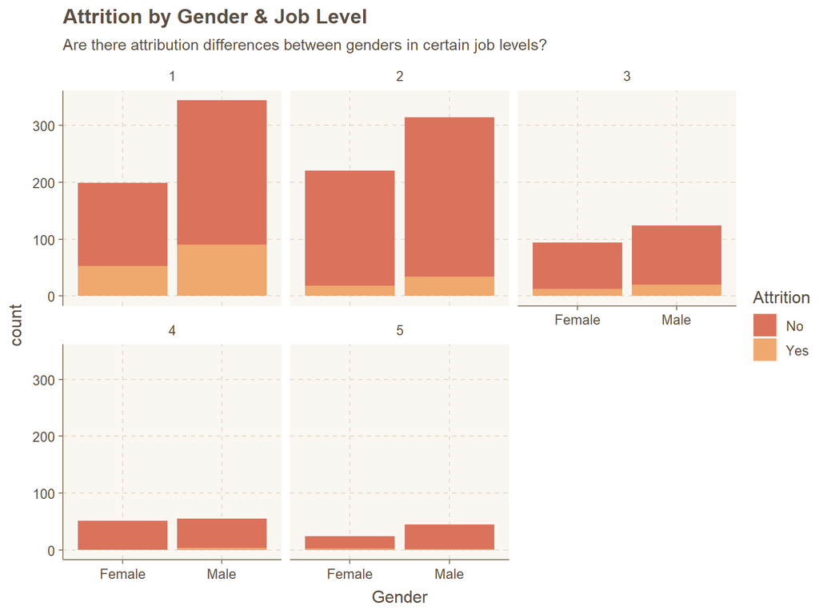

```r
f_data %>%
  ggplot(aes(x = Gender,  fill = Attrition)) +
  geom_bar()  +
  facet_wrap(vars(JobLevel)) +
  labs(title = "Attrition by Gender & Job Level",  subtitle = "Are there attribution differences between genders in certain job levels?")
```

**Quick Takeaways:**

- Overall, the attrition rate between gender seem relatively well distributed between job levels.

**Hypotheses to Test:**

1. Individuals are leaving the organization due to low income.
2. Individuals are leaving the organization due to low income in comparison to their peers within their job role, department, or level. This may be caused by a low perception of organizational fairness.
3. Individuals who earn more are more satisfied with their jobs.